# 市场观察

2017/08/08

## A、指数估值

### (a1)动态市盈率、市净率

核心指数成分股近18个月的动态市盈率及动态市净率中位数走势如下图所示：

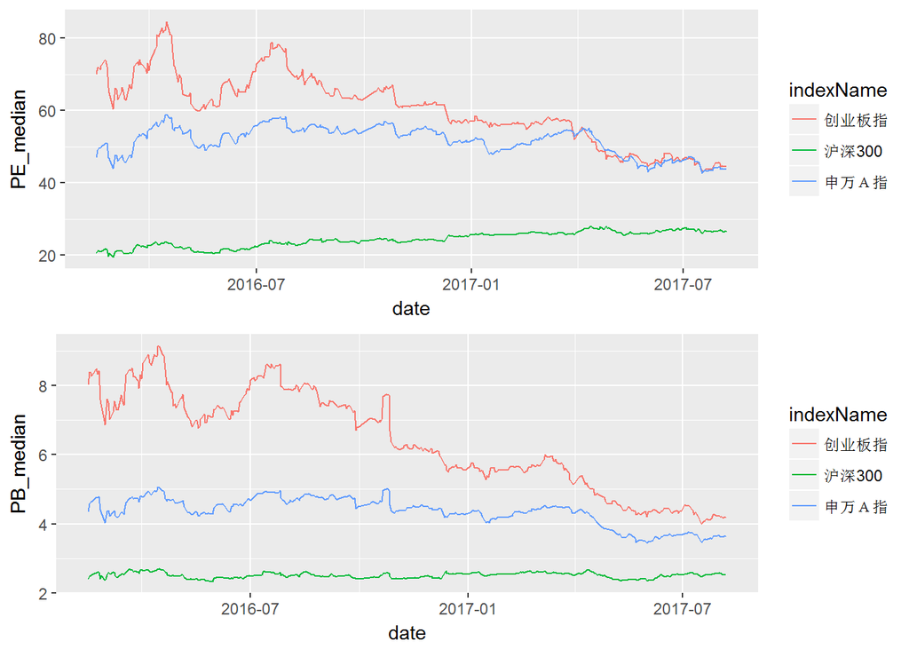

### (a2)动态市盈率、市净率百分位

核心指数近18个月的动态市盈率百分位及动态市净率百分位走势如下图所示：

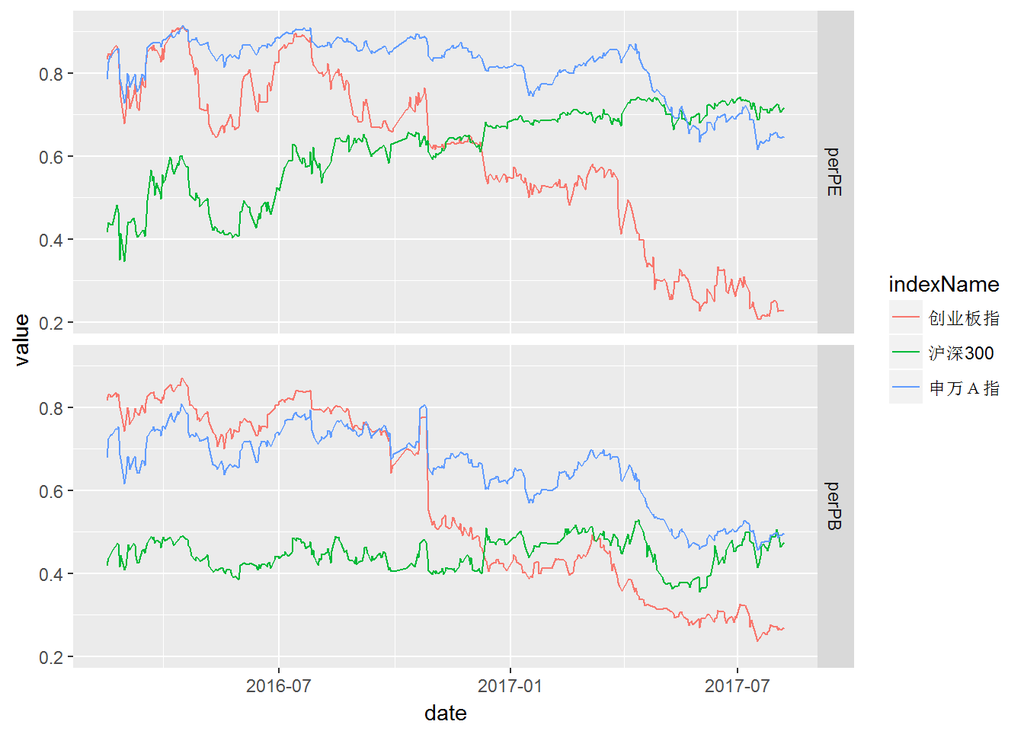

### (a3)指数估值概览

纳入观察的指数最新的估值情况如下表，根据市盈率和市净率分位数均值降序排列。

| 指数代码 | 指数简称 | 日期 | 动态市盈率 | 市盈率百分位 | 动态市净率 | 市净率百分位 |
| --- | --- | --- | --- | --- | --- | --- |
| EI000819 | 有色金属 | 2017-08-07 | 64.9 | 89% | 3.8 | 77% |
| EI000979 | 大宗商品 | 2017-08-07 | 41.0 | 76% | 2.8 | 63% |
| EI000300 | 沪深300 | 2017-08-07 | 26.8 | 72% | 2.5 | 47% |
| EI801003 | 申万Ａ指 | 2017-08-07 | 44.0 | 65% | 3.7 | 50% |
| EI399330 | 深证100 | 2017-08-07 | 32.1 | 64% | 3.4 | 43% |
| EI399959 | 军工指数 | 2017-08-07 | 81.4 | 55% | 3.9 | 49% |
| EI399005 | 中小板指P | 2017-08-07 | 38.1 | 52% | 4.4 | 38% |
| EI000905 | 中证500 | 2017-08-07 | 35.9 | 48% | 2.9 | 34% |
| EI000934 | 中证金融 | 2017-08-07 | 19.1 | 63% | 1.8 | 19% |
| EI000922 | 中证红利 | 2017-08-07 | 16.9 | 50% | 1.7 | 24% |
| EI000998 | 中证TMT | 2017-08-07 | 41.8 | 41% | 3.6 | 30% |
| EI000932 | 中证消费 | 2017-08-07 | 31.1 | 45% | 3.7 | 24% |
| EI000016 | 上证50 | 2017-08-07 | 16.5 | 48% | 1.6 | 15% |
| EI000827 | 中证环保 | 2017-08-07 | 35.1 | 27% | 3.1 | 28% |
| EI399006 | 创业板指 | 2017-08-07 | 44.7 | 23% | 4.2 | 27% |
| EI000933 | 中证医药 | 2017-08-07 | 32.2 | 18% | 3.6 | 2% |

### (a4)另类估值

我国10年期国债收益率、金银比价、金油比价，2000年以来的历史百分位如下图所示：

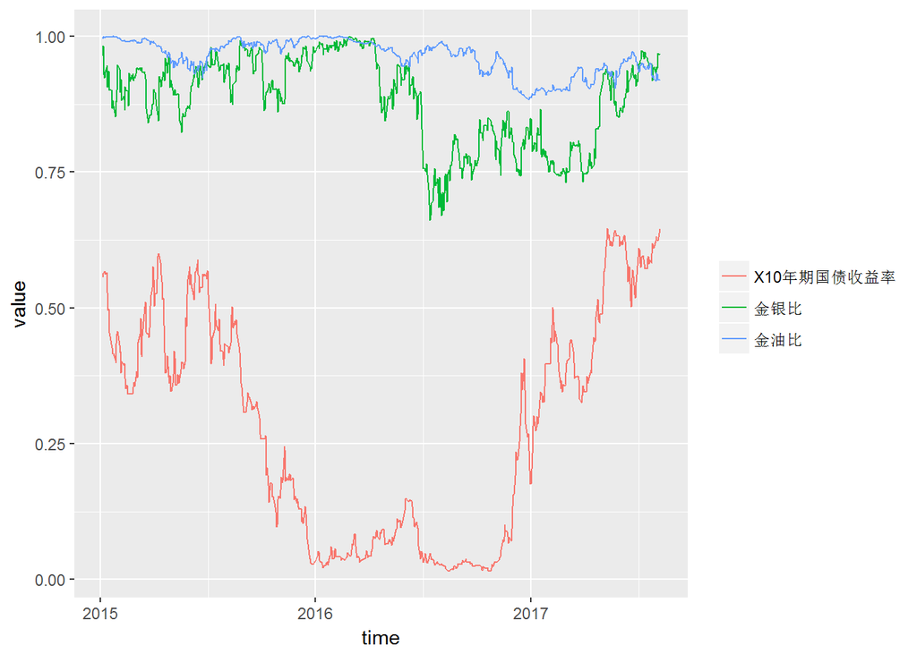

## B、基差及市场情绪

### (b1)基差走势

三大股指期货合约基差走势如下图，其中当月合约和次月合约年化基差百分比波动较大，仅展示合约基差百分比，当季合约和次季合约展示基差年化百分比：

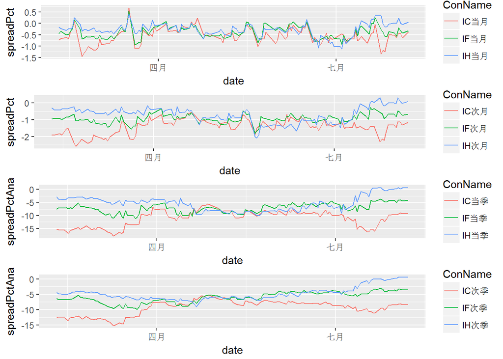

### (b2)基差概况

三大股指期货连续合约基差概况如下表，近月合约临近到期日，年化基差百分比数据波动较大：

| 日期 | 合约代码 | 合约收盘价 | 指数收盘价 | 基差 | 基差百分比 | 年化基差百分比 |
| --- | --- | --- | --- | --- | --- | --- |
| 2017-08-07 | IC1708 | 6280.0 | 6303.4 | -23.4 | -0.4% | -13.1% |
| 2017-08-07 | IC1709 | 6230.0 | 6303.4 | -73.4 | -1.2% | -11.4% |
| 2017-08-07 | IC1712 | 6100.8 | 6303.4 | -202.6 | -3.2% | -9.3% |
| 2017-08-07 | IC1803 | 5993.0 | 6303.4 | -310.4 | -4.9% | -8.3% |
| 2017-08-07 | IF1708 | 3715.0 | 3726.8 | -11.8 | -0.3% | -11.1% |
| 2017-08-07 | IF1709 | 3702.0 | 3726.8 | -24.8 | -0.7% | -6.4% |
| 2017-08-07 | IF1712 | 3672.2 | 3726.8 | -54.6 | -1.5% | -4.2% |
| 2017-08-07 | IF1803 | 3649.6 | 3726.8 | -77.2 | -2.1% | -3.4% |
| 2017-08-07 | IH1708 | 2635.6 | 2634.2 | 1.4 | 0.1% | 1.8% |
| 2017-08-07 | IH1709 | 2636.8 | 2634.2 | 2.6 | 0.1% | 0.9% |
| 2017-08-07 | IH1712 | 2640.0 | 2634.2 | 5.8 | 0.2% | 0.6% |
| 2017-08-07 | IH1803 | 2643.8 | 2634.2 | 9.6 | 0.4% | 0.6% |

### (b3)市场情绪(provided by han.qian)

市场情绪记录近60天每天自然涨跌停(剔除一字板)、创60日新高新低、多头排列空头排列(均线组合5,30,60,120)的股票数。

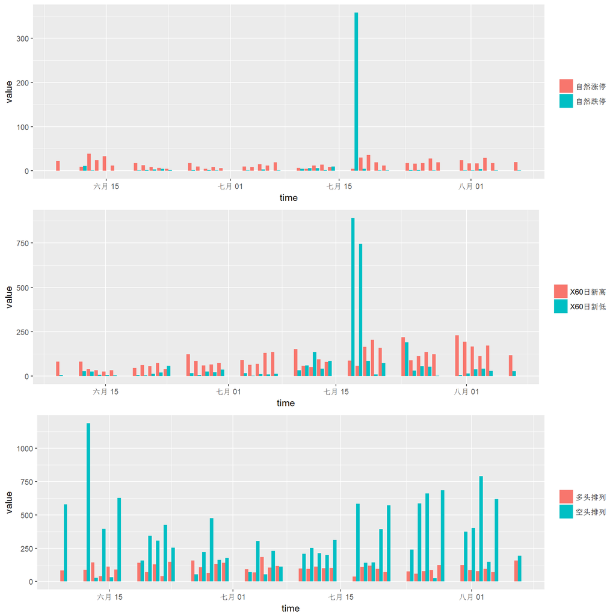

## C、套利和事件

### (c1)复牌股票套利

近两天复牌股票套利情况如下表：

[1] “No Arbitrage!”

### (c2)解禁

解禁分成两个部分，定增解禁和IPO解禁，涨跌幅记录是过去十个交易日的股票涨跌幅和对应行业指数涨跌幅。伴随着去年下半年IPO逐步正常化，今后IPO解禁给市场造成的抛压会持续存在，所以纳入观察。近期定增解禁的股票情况如下表。

| 股票代码 | 股票简称 | 解禁日 | 解禁数量 | 解禁百分比 | 区间涨跌幅 | 所属行业指数 | 行业指数涨跌幅 |
| --- | --- | --- | --- | --- | --- | --- | --- |
| EQ300158 | 振东制药 | 2017-08-10 | 1.47 | 51% | 2.7% | 申万医药生物 | 0.7% |
| EQ002149 | 西部材料 | 2017-08-11 | 0.76 | 22% | 14.1% | 申万有色金属 | 10.5% |
| EQ600577 | 精达股份 | 2017-08-14 | 5.36 | 38% | 0.2% | 申万机械设备 | 1.2% |
| EQ300364 | 中文在线 | 2017-08-15 | 1.07 | 31% | 0.0% | 申万传媒 | 3.2% |
| EQ002092 | 中泰化学 | 2017-08-15 | 3.39 | 20% | 13.7% | 申万化工 | 2.8% |
| EQ600418 | 江淮汽车 | 2017-08-15 | 4.30 | 42% | -0.5% | 申万汽车 | -1.5% |
| EQ002193 | 如意集团 | 2017-08-16 | 0.71 | 45% | 5.1% | 申万纺织服装 | -0.6% |
| EQ002743 | 富煌钢构 | 2017-08-21 | 0.89 | 78% | -0.4% | 申万建筑装饰 | -3.1% |
| EQ600175 | 美都能源 | 2017-08-21 | 10.03 | 69% | 0.7% | 申万综合 | 3.7% |
| EQ600075 | 新疆天业 | 2017-08-21 | 2.18 | 36% | 5.9% | 申万化工 | 2.8% |
| EQ601137 | 博威合金 | 2017-08-21 | 1.34 | 31% | 7.6% | 申万有色金属 | 10.5% |
| EQ002199 | 东晶电子 | 2017-08-21 | 0.54 | 41% | -4.8% | 申万电子 | -1.5% |
| EQ002371 | 北方华创 | 2017-08-22 | 1.85 | 111% | -1.7% | 申万电子 | -1.5% |
| EQ600661 | 新南洋 | 2017-08-22 | 0.78 | 43% | 2.4% | 申万传媒 | 3.2% |
| EQ000719 | 大地传媒 | 2017-08-22 | 3.56 | 53% | -0.1% | 申万传媒 | 3.2% |
| EQ002772 | 众兴菌业 | 2017-08-22 | 0.54 | 33% | -0.7% | 申万农林牧渔 | 1.0% |

近期IPO解禁的股票情况如下表。

| 股票代码 | 股票简称 | 解禁日 | 解禁数量 | 解禁百分比 | 区间涨跌幅 | 所属行业指数 | 行业指数涨跌幅 | 上市日 |
| --- | --- | --- | --- | --- | --- | --- | --- | --- |
| EQ600977 | 中国电影 | 2017-08-09 | 0.98 | 21% | 4.6% | 申万传媒 | 3.2% | 2016-08-09 |
| EQ300530 | 达志科技 | 2017-08-09 | 0.04 | 20% | -1.6% | 申万化工 | 2.8% | 2016-08-09 |
| EQ300531 | 优博讯 | 2017-08-09 | 0.52 | 74% | -5.1% | 申万通信 | -0.1% | 2016-08-09 |
| EQ603569 | 长久物流 | 2017-08-10 | 0.17 | 43% | -1.3% | 申万交通运输 | 1.1% | 2016-08-10 |
| EQ600936 | 广西广电 | 2017-08-14 | 8.96 | 299% | 1.2% | 申万传媒 | 3.2% | 2016-08-15 |
| EQ002808 | 苏州恒久 | 2017-08-14 | 0.41 | 86% | 4.2% | 申万电子 | -1.5% | 2016-08-12 |
| EQ300535 | 达威股份 | 2017-08-14 | 0.17 | 112% | -0.3% | 申万化工 | 2.8% | 2016-08-12 |
| EQ601997 | 贵阳银行 | 2017-08-16 | 8.65 | 173% | -2.8% | 申万银行 | -0.4% | 2016-08-16 |
| EQ300348 | 长亮科技 | 2017-08-17 | 0.44 | 27% | 3.6% | 申万计算机 | 2.5% | 2012-08-17 |
| EQ300532 | 今天国际 | 2017-08-18 | 0.28 | 74% | 27.4% | 申万计算机 | 2.5% | 2016-08-18 |
| EQ300533 | 冰川网络 | 2017-08-18 | 0.31 | 125% | -0.7% | 申万传媒 | 3.2% | 2016-08-18 |
| EQ603986 | 兆易创新 | 2017-08-18 | 0.97 | 195% | 9.9% | 申万电子 | -1.5% | 2016-08-18 |
| EQ603515 | 欧普照明 | 2017-08-21 | 0.40 | 69% | 2.8% | 申万电子 | -1.5% | 2016-08-19 |
| EQ603099 | 长白山 | 2017-08-22 | 1.64 | 160% | 1.3% | 申万休闲服务 | -0.4% | 2014-08-22 |
| EQ603031 | 安德利 | 2017-08-22 | 0.20 | 100% | -15.5% | 申万食品饮料 | 2.0% | 2016-08-22 |

### (c3)中小板业绩预增预测(provided by han.qian)

中小板规定正式财务报告发布的同时需要发布新一期的业绩预报，比如年报中会包含一季报预告的情况。我们假设公司的盈利状况有动量效应，年报预增的公司一季度也会预增，在正式财务报告发布前20个交易日开始埋伏，然后等正式报告发布日卖出。具体研究参见钱瀚前期的研究。需要注意的是这里的收益率仅做展示，仅仅是每日全部入选股票的平均收益率，并没有做成一个事件组合。

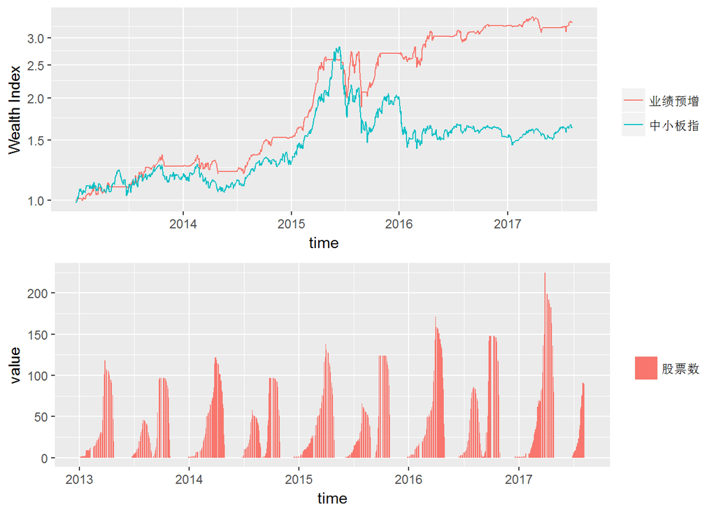

历年收益统计如下表所示。

|  | 业绩预增 | 中小板指 |
| --- | --- | --- |
| 2013-01-04 ~ 2013-12-31 | 26.0% | 17.5% |
| 2014-01-02 ~ 2014-12-31 | 21.4% | 9.7% |
| 2015-01-05 ~ 2015-12-31 | 76.6% | 53.7% |
| 2016-01-04 ~ 2016-12-30 | 21.1% | -22.9% |
| 2017-01-03 ~ 2017-08-07 | 2.4% | 7.5% |
| Cumulative Return | 234.8% | 64.3% |
| Annualized Return | 30.1% | 11.4% |